# The Elo method in chess

**Elo method** was coined by the physics professor and excellent chess player Arpad Elo. In 1970, FIDE, the World Chess Federation, agreed to adopt the Elo Rating System.

The method works as follows. Suppose that players $i$ and $j$ match. Let $s_{i,j}$ be the **actual score** of $i$ in the match against $j$. We have that:

- $s_{i,j} = 1$ if $i$ wins;
- $s_{i,j} = 0$ if $i$ loses; and
- $s_{i,j} = 0.5$ if there is a draw.

Notice that the actual score $s_{j,i}$ of $j$ in the match against $i$ is $1 - s_{i,j}$. Let $\mu_{i,j}$ be the **expected score** of $i$ in the match against $j$. We have that:

$$\begin{array}{lll}
\mu_{i,j} & = & \frac{1}{1 + 10^{-(r_i - r_j) / \zeta}} =
\frac{10^{r_i / \zeta}}{10^{r_i / \zeta} + 10^{r_j / \zeta}} \\\\
\end{array}$$

with $r_i$ and $r_j$ the ratings of $i$ and $j$ before the match and $\zeta$ is a constant. Notice that the expected score $\mu_{j,i}$ of $j$ in the match against $i$ is $1 - \mu_{i,j}$.

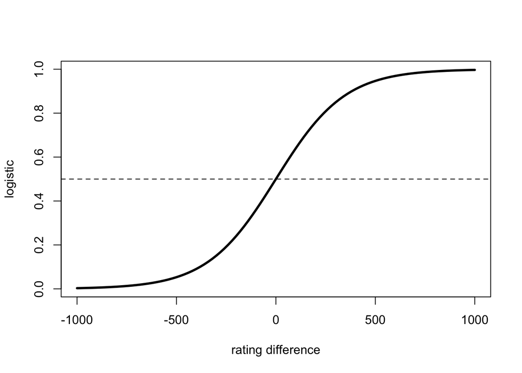

We assume that initially all player ratings are equal to 0. When players $i$ and $j$ match, the new ratings $r_i$ of $i$ and $r_j$ of $j$ are modified using the following update rule:

$$\begin{array}{lll}
r_{i} & \leftarrow & r_i + \kappa (s_{i,j} - \mu_{i,j})
\\
r_j & \leftarrow & r_j + \kappa (s_{j,i} - \mu_{j,i})
\end{array}$$

where $\kappa$ is a constant.

The Elo thesis is:

> *If a player performs as expected, it gains nothing. If it performs better than expected, it is rewarded, while if it performs poorer than expected, it is penalized.*

This challenge is ispired by [Chess ratings - Elo versus the Rest of the World](https://www.kaggle.com/c/chess#description) Kaggle competition.

## Downloads

- A CSV with outcomes of 65053 distinct chess games (White, Black and Score). The possible values for Score represent the three possible outcomes of a chess game (1=White wins, 0.5=draw, 0=Black wins). Read [details](https://www.kaggle.com/c/chess/data).

## Challenges

```r
library(tidyverse)

games <- read_csv("data.csv")

games
```

```
## # A tibble: 65,053 × 3
##    White Black Score
##    <dbl> <dbl> <dbl>
##  1    73  1246   0.5
##  2    73  5097   0.5
##  3    73  5104   0.5
##  4    73  7321   1
##  5    73  7375   0.5
##  6    88  1033   0.5
##  7    88  1860   1
##  8    88  4858   1
##  9   154  3377   0
## 10   158  8059   1
## # ℹ 65,043 more rows
```

```r
count(games, Score)
```

```
## # A tibble: 3 × 2
##   Score     n
##   <dbl> <int>
## 1   0   15224
## 2   0.5 28666
## 3   1   21163
```

# 1. Has the White an advantage over the Black, that is, is there a first-mover advantage?

```r
games |>
  count(Score) |>
  mutate(share = n / sum(n))
```

```
## # A tibble: 3 × 3
##   Score     n share
##   <dbl> <int> <dbl>
## 1   0   15224 0.234
## 2   0.5 28666 0.441
## 3   1   21163 0.325
```

```r
games |>
  summarise(mean_score = mean(Score))
```

```
## # A tibble: 1 × 1
##   mean_score
##        <dbl>
## 1      0.546
```

```r
set.seed(42)

n_games <- nrow(games)
n_sim <- 1000
sim_means <- vector("double", n_sim)

for (i in 1:n_sim) {
  coin <- sample(c("H", "T"), n_games, replace = TRUE)
  sim_score <- ifelse(coin == "H", games$Score, 1 - games$Score)
  sim_means[i] <- mean(sim_score)
}

obs_mean <- mean(games$Score)

obs_mean
```

```
## [1] 0.5456474
```

```r
sum(sim_means >= obs_mean) / n_sim
```

```
## [1] 0
```

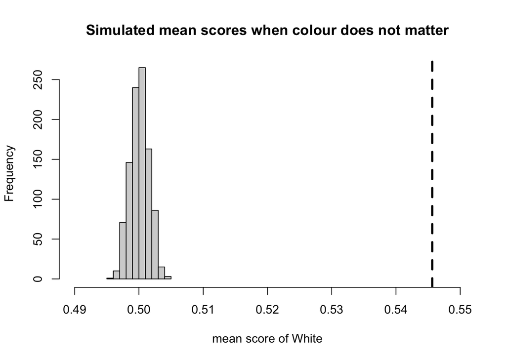

```r
hist(sim_means,
     xlim = c(0.49, 0.55),
     xlab = "mean score of White",
     main = "Simulated mean scores when colour does not matter")
abline(v = obs_mean, lwd = 3, lty = 2)
```

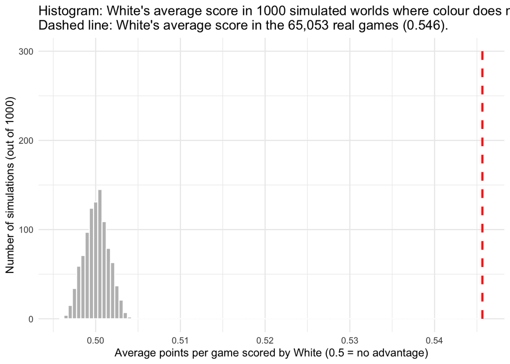

```r
data.frame(sim_means) |>
  ggplot(aes(x = sim_means)) +
  geom_histogram(binwidth = 0.0005, fill = "grey", colour = "white") +
  geom_segment(data = data.frame(obs_mean),
               aes(x = obs_mean, xend = obs_mean, y = 0, yend = 300),
               colour = "red", linetype = "dashed", linewidth = 1) +
  labs(
    title = "Histogram: White's average score in 1000 simulated worlds where colour does not matter.
Dashed line: White's average score in the 65,053 real games (0.546).",
    x = "Average points per game scored by White (0.5 = no advantage)",
    y = "Number of simulations (out of 1000)"
  ) +
  theme_minimal()
```

Si, il bianco ottiene in media 0,546 punti a partita contro lo 0,5 atteso senza vantaggio (vince il 32,5% delle partite contro il 23,4% del Nero), e nessuna delle 1000 simulazioni in cui il colore non conta raggiunge questo valore (p-value inferiore a 1 su 1000). C’è, quindi, un vantaggio reale, di entità moderata, coerente con un vantaggio della prima mossa.

# 1. Write a function that computes the player point rating (1 point for wins, 0.5 points for draws, 0 points for defeats). How are point ratings distributed? Why?

```r
point_rating <- function(games) {

  stacked <- data.frame(
    player = c(games$White, games$Black),
    points = c(games$Score, 1 - games$Score)
  )

  result <- stacked |>
    group_by(player) |>
    summarise(points = sum(points))

  return(result)
}

point_ratings <- point_rating(games)

point_ratings
```

```
## # A tibble: 7,301 × 2
##    player points
##     <dbl>  <dbl>
##  1      1   31
##  2      2    0.5
##  3      3    3
##  4      4   23.5
##  5      5    4
##  6      6    7
##  7      7   14
##  8      8    0
##  9      9    0.5
## 10     10    3
## # ℹ 7,291 more rows
```

```r
sum(point_ratings$points)
```

```
## [1] 65053
```

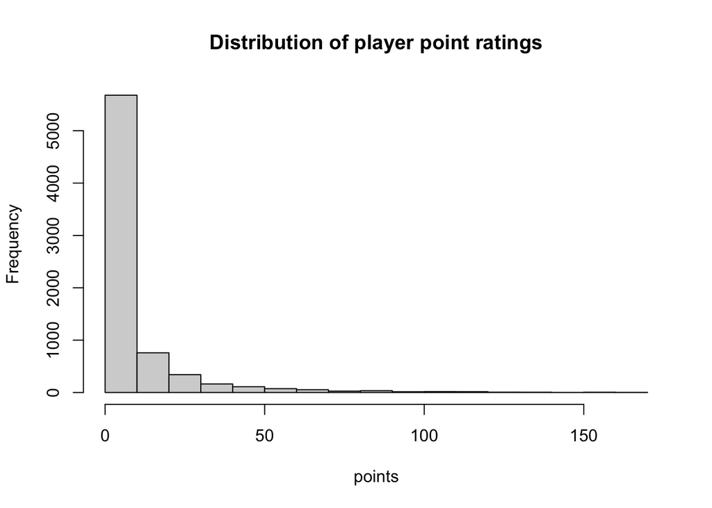

```r
hist(point_ratings$points,
     xlab = "points",
     main = "Distribution of player point ratings")
```

```r
mean(point_ratings$points)
```

```
## [1] 8.910149
```

```r
nrow(filter(point_ratings, points <= 5)) / nrow(point_ratings)
```

```
## [1] 0.6425147
```

Il sistema basato sui punti (1 point for wins, 0.5 points for draws, 0 points for defeats) vede una distribuzione molto asimmetrica, poiché la maggior parte dei giocatori ha pochissimi punti, mentre pochi giocatori arrivano a punteggi molto alti, formando cosi una lunga coda a destra. Il motivo è che il sistema a punti si basa su una somma sulle partite giocate e il numero di partite è molto diseguale tra i giocatori, pochi giocano moltissimo, la maggior parte pochissimo. Chi ha giocato di più accumula più punti anche senza essere più forte, quindi, il sistema a punti misura soprattutto l’attività di gioco più che la bravura del giocatore.

# 2. An interesting property of Elo’s ratings is that the sum of all player ratings is always 0. Formally show this property. (Hint: use the fact that $s_{i,j} + s_{j,i}=1$ and $\mu_{i,j} + \mu_{j,i} =1$)

All’inizio tutti i rating sono uguali a 0, quindi, la loro somma è 0. Mostriamo che una partita non modifica la somma dei rating, così, partita dopo partita, la somma resta 0.

Supponiamo che i giocatori “i” e “j” giochino una partita, alla fine cambiano i loro rating e per la regola di aggiornamento (che usa i rating di prima della partita) la somma varia di

$$\kappa (s_{i,j} - \mu_{i,j}) + \kappa (s_{j,i} - \mu_{j,i}) = \kappa
\left[ (s_{i,j} + s_{j,i}) - (\mu_{i,j} + \mu_{j,i}) \right].$$

$$\mu_{i,j} + \mu_{j,i} = \frac{10^{r_i / \zeta}}{10^{r_i / \zeta} +
10^{r_j / \zeta}} + \frac{10^{r_j / \zeta}}{10^{r_i / \zeta} + 10^{r_j /
\zeta}} = 1.$$

Quindi, la variazione della somma è k(1 - 1) = 0 e la partita non cambia la somma dei rating, poiché la somma iniziale è 0, resta 0 dopo ogni partita.

# 3. Write a function that computes the player Elo rating (set $\zeta = 400$ and $\kappa = 25$) (Hint: take advantage of the 0-sum property to optimize the code). Obserse its distribution: why is different from the point distribution? Verify the 0-sum property for Elo’s ratings

```r
elo_rating <- function(games, zeta = 400, kappa = 25) {

  players <- point_rating(games)$player

  ratings <- vector("double", length(players))
  names(ratings) <- players

  for (g in 1:nrow(games)) {
    white <- paste(games$White[g])
    black <- paste(games$Black[g])

    mu <- logistic(ratings[white] - ratings[black], zeta)
    delta <- kappa * (games$Score[g] - mu)

    ratings[white] <- ratings[white] + delta
    ratings[black] <- ratings[black] - delta
  }

  names(ratings) <- NULL

  return(data.frame(player = players, elo = ratings))
}

elo_ratings <- elo_rating(games)

sum(elo_ratings$elo)
```

```
## [1] 2.621192e-11
```

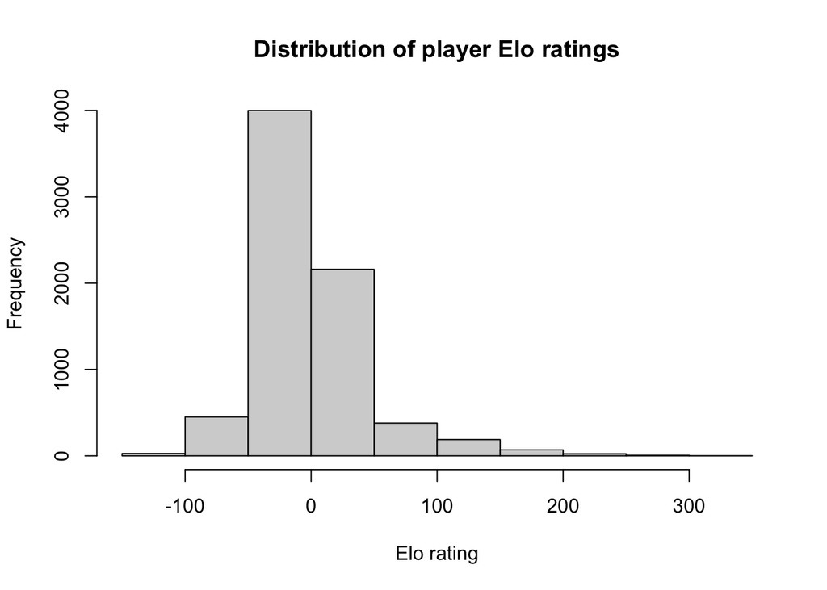

```r
hist(elo_ratings$elo,
     xlab = "Elo rating",
     main = "Distribution of player Elo ratings")
```

# 4. Are point and Elo ratings correlated? Are top Elo players overlapping with top point players?

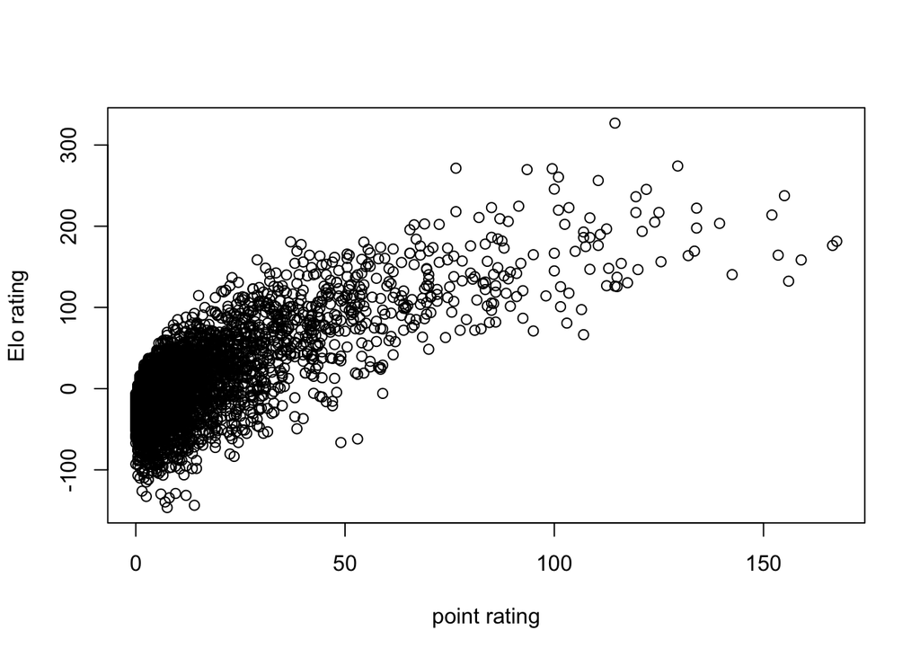

```r
ratings <- inner_join(point_ratings, elo_ratings, join_by(player))

plot(ratings$points, ratings$elo,
     xlab = "point rating",
     ylab = "Elo rating")
```

```r
cor(ratings$points, ratings$elo)
```

```
## [1] 0.7198872
```

```r
top_points <- ratings |>
  arrange(desc(points)) |>
  head(100) |>
  select(player)

top_elo <- ratings |>
  arrange(desc(elo)) |>
  head(100) |>
  select(player)

nrow(intersect(top_points, top_elo))
```

```
## [1] 53
```

Sì, il sistema a punti e l’Elo sono correlati, il coefficiente di correlazione è circa 0,72, quindi, i due rating tendono ad aumentare insieme. Va, però, letto con cautela, perché la correlazione di Pearson è sensibile ai pochi giocatori con valori estremi e parte dell’associazione dipende dal fatto che entrambi i rating crescono con il numero di partite giocate. Anche i migliori si sovrappongono solo in parte, infatti, tra i primi 100 per punti e i primi 100 per Elo, 53 giocatori sono in comune.

# 5. Test if the number of played games has an effect on the Elo and point player ratings

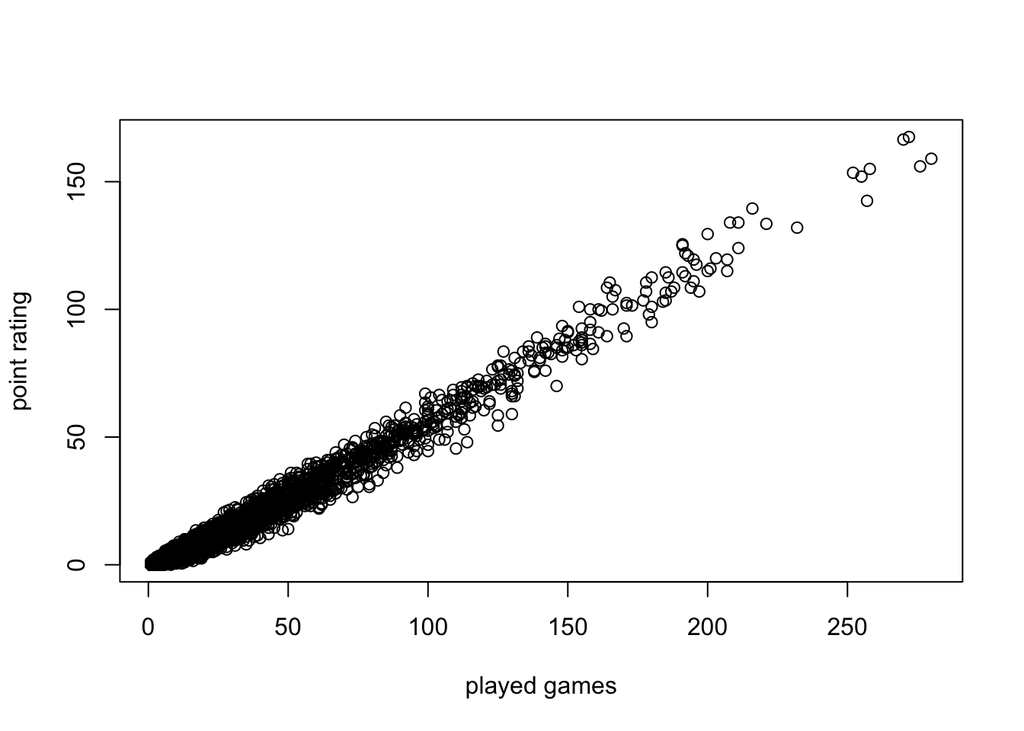

```r
games_played <- data.frame(player = c(games$White, games$Black)) |>
  count(player)

ratings_games <- inner_join(ratings, games_played, join_by(player))

plot(ratings_games$n, ratings_games$points,
     xlab = "played games",
     ylab = "point rating")
```

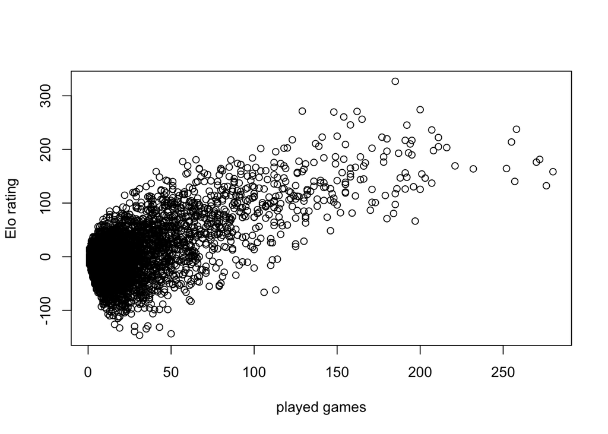

```r
plot(ratings_games$n, ratings_games$elo,
     xlab = "played games",
     ylab = "Elo rating")
```

```r
cor(ratings_games$n, ratings_games$points)
```

```
## [1] 0.9900841
```

```r
cor(ratings_games$n, ratings_games$elo)
```

```
## [1] 0.6387939
```

```r
set.seed(42)

n_sim <- 1000
sim_cor_points <- vector("double", n_sim)
sim_cor_elo <- vector("double", n_sim)

for (i in 1:n_sim) {
  shuffled <- sample(ratings_games$n)
  sim_cor_points[i] <- cor(shuffled, ratings_games$points)
  sim_cor_elo[i] <- cor(shuffled, ratings_games$elo)
}

obs_cor_points <- cor(ratings_games$n, ratings_games$points)
obs_cor_elo <- cor(ratings_games$n, ratings_games$elo)

sum(sim_cor_points >= obs_cor_points) / n_sim
```

```
## [1] 0
```

```r
sum(sim_cor_elo >= obs_cor_elo) / n_sim
```

```
## [1] 0
```

Sì, vi è un’associazione tra il numero di partite giocate ed entrambi i punteggi. Ho realizzato due scatterplot per mostrare la relazione tra le partite giocate e ciascun punteggio, si può osservare che nel sistema a punti crescono quasi in linea retta con le partite (correlazione: 0,99), mentre l’Elo mostra un’associazione positiva più debole e con molta più dispersione (correlazione: 0,64). Come nella domanda 1, ho poi aggiunto un test di permutazione per una verifica più solida, poiché rimescolando a caso il numero di partite tra i giocatori, nessuna delle 1000 correlazioni simulate raggiunge quella osservata (p-value: 0), né per i punti né per l’Elo. L’effetto è, però, di natura diversa nei due casi, poiché per il sistema a punti è quasi meccanico, dato che ogni partita assegna punti, invece, per l’Elo non lo è, in quanto l’associazione può dipendere dal fatto che i giocatori più forti giocano di più e che chi gioca poco resta vicino al rating iniziale 0.